# Overdispersion in binary data

15 May 2026

## Goals for today

- Understand how to evaluate goodness-of-fit for binomial data
- Understand the notion of *overdispersion* in binomial data
- Understand the options for modeling overdispersed binomial data
- Understand the pros & cons of the modeling options

## Goodness-of-fit

How well does our model fit the data?

A simple check is a \(\chi^2\) test for the *standardized residuals*

\[ e_i = \frac{y_i - \hat{y}_i}{\text{SD}(y_i)} = \frac{y_i - \hat{y}_i}{\sqrt{(\hat{y}_i (1 - \hat{y}_i))}} \\ \Downarrow \\ \sum_{i = 1}^n e_i \sim \chi^2_{(n - k - 1)} \]

## Smolt age versus length

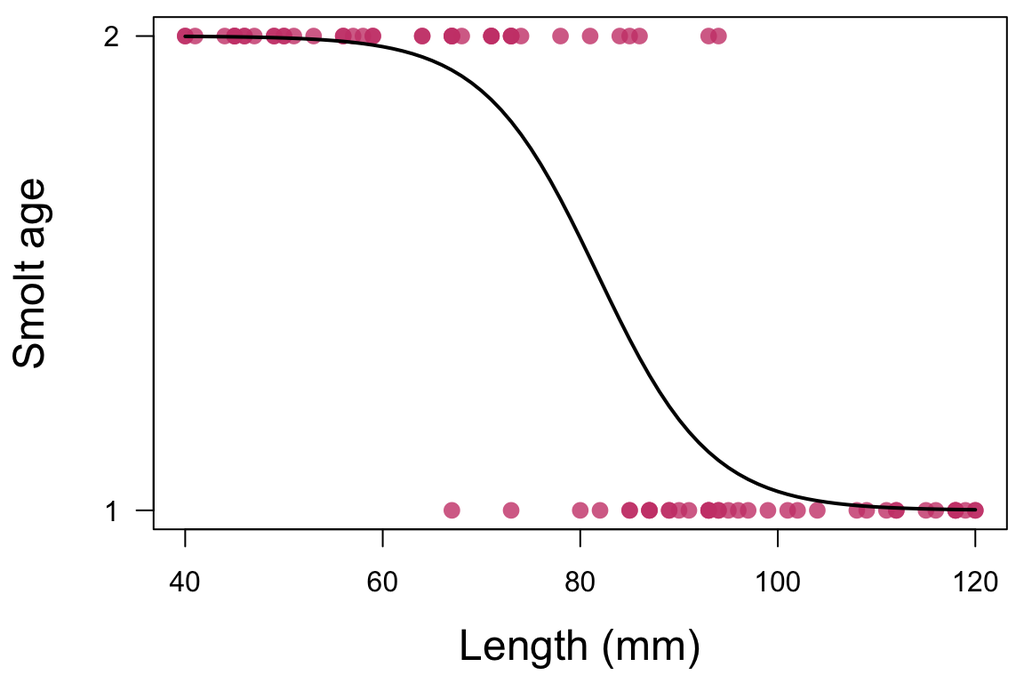

## Smolt age versus length

```r
## residuals
ee <- residuals(fit_mod, type = "response")
## fitted values
y_hat <- fitted(fit_mod)
## standardized residuals
rr <- ee / (y_hat * (1 - y_hat))
## test stat
x2 <- sum(rr)
## chi^2 test
pchisq(x2, nn - length(coef(fit_mod)) - 1, lower.tail = FALSE)
```

```
## [1] 1
```

The \(p\)-value is large so we detect no lack of fit

## Binned predictions

It’s hard to compare our predictions on the interval [0,1] to discrete binary outcomes {0,1}

To help, we can compute \(\hat{y}\) for *bins of data*

## Binned predictions

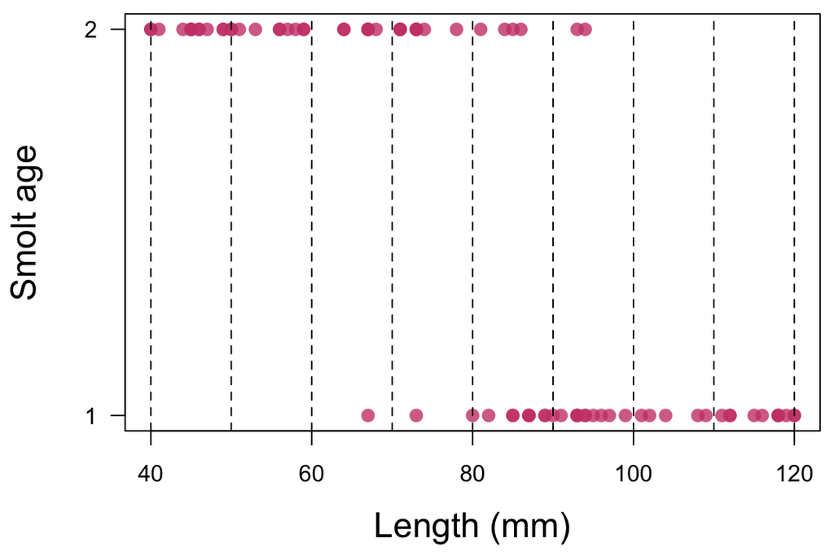

## Binned predictions

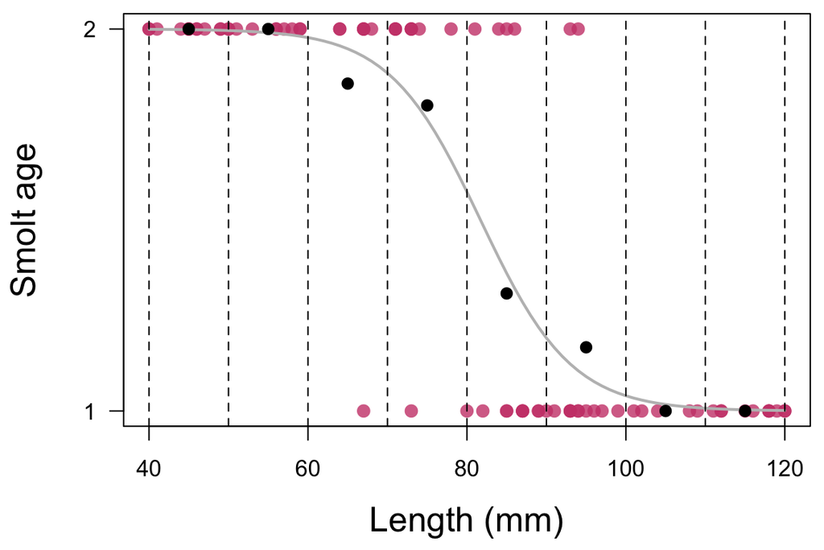

## Binned predictions

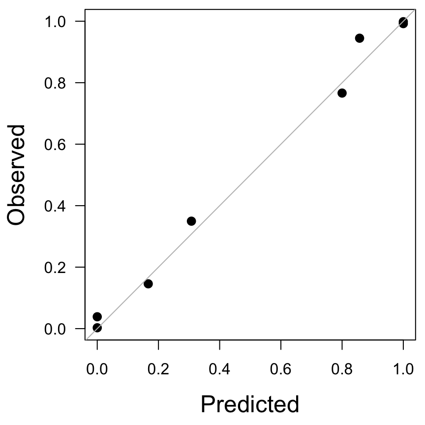

## Hosmer-Lemeshow test

We can formalize this binned comparison with the Hosmer-Lemeshow test

\[ HL = \sum_{j = 1}^J \frac{(y_j - m_j \hat{p}_J)^2}{m_j \hat{p}_J(1 - \hat{p}_J)} \sim \chi^2_{(J - 1)} \]

where \(J\) is the number of groups and \(y_j = \sum y_{i = j}\)

## Hosmer-Lemeshow test

We can perform the H-L test with `generalhoslem::logitgof()`

```r
## H-L test with 8 groups
generalhoslem::logitgof(obs = df$age, exp = fitted(fit_mod), g = 8)
```

```
##
##  Hosmer and Lemeshow test (binary model)
##
## data:  df$age, fitted(fit_mod)
## X-squared = 1.35, df = 6, p-value = 0.9688
```

The \(p\)-value is large so we conclude an adequate fit

## Classification scoring

Another means for evaluating goodness-of-fit is *classification scoring*

We can use our model to predict the outcome for each individual, such that

- if \(p_i < 0.5\) then \(\hat{y}_i = 0\)
- if \(p_i \geq 0.5\) then \(\hat{y}_i = 1\)

## Classification scoring

```r
## predicted ages
pred_age <- ifelse(fitted(fit_mod) < 0.5, 1, 2)
## observed ages
obs_age = df$age + 1
## contingency table
(ct <- xtabs(~ obs_age + pred_age))
```

```
##        pred_age
## obs_age  1  2
##       1 35  3
##       2  5 37
```

```r
## correct classification
sum(diag(ct)) / nn
```

```
## [1] 0.9
```

## Classification scoring

### Sensitivity

Ability to predict age-2 when fish *do* smolt at age-2 (“true positive”)

```
##        pred_age
## obs_age  1  2
##       1 35  3
##       2  5 37
```

37 / (5 + 37) = 88.1%

## Classification scoring

### Specificity

Ability to predict age-1 when fish *do* smolt at age-1 (“true negative”)

```
##        pred_age
## obs_age  1  2
##       1 35  3
##       2  5 37
```

35 / (35 + 3) = 92.1%

## Proportion of variance explained

Calculating \(R^2\) for logistic models is not the same as linear models

Given the deviance \(D_M\) for our model and a null model \(D_0\),

\[ R^2 = \frac{1 - \exp \left( [D_M - D_0]/n \right)}{1 - \exp(\text{-}D_0 / n)} \]

## Proportion of variance explained

Here is the \(R^2\) for our smolt-at-age model

```r
## deviances
DM <- fit_mod$deviance
D0 <- fit_mod$null.deviance
# R^2
R2 <- (1 - exp((DM - D0) / nn)) / (1 - exp(-D0 / nn))
round(R2, 2)
```

```
## [1] 0.78
```

## QUESTIONS?

## Lack of fit

If our model fits the data well, we expect the deviance \(D\) to be \(\chi^2\) distributed

Sometimes, however, the deviance is larger than expected

## Lack of fit

What leads to a lack of fit?

- model mis-specification
- outliers
- non-linear relationship between \(x\) and \(\eta\)
- non-independence in the observed data

## Overdispersion

Recall that the variance for a binomial of size \(n\) is given by

\[ \text{Var}(y) = n p (1 - p) \]

If \(\text{Var}(y) > n p (1 - p)\) this is called *overdispersion*

## Overdispersion

Overdispersion generally arises in 2 ways related to IID errors

1. trials occur in groups & \(p\) is not constant among groups
2. trials are not independent

## Overdispersion

To address overdispersion, we can include the *dispersion* parameter \(c\), such that

\[ \text{Var}(y) = c n p (1 - p) \]

\(c\) is also called the *variance inflation factor*

## Overdispersion

We can estimate \(c\) from the deviance \(D\) as

\[ \hat{c} = \frac{D}{n - k} \]

## Aside: Pearson’s \(\chi^2\) statistic

Pearson’s \(\chi^2\) statistic is similar to the deviance

\[ X^2 = \sum_{i = 1}^n \frac{(O_i - E_i)^2}{E_i} \sim \chi^2_{(n - 1)} \]

where \(O_i\) is the observed count and \(E_i\) is the expected count

## Aside: Pearson’s \(\chi^2\) statistic

For a binomial distribution

\[ X^2 = \sum_{i = 1}^n \frac{(O_i - E_i)^2}{E_i} \\ \Downarrow \\ X^2 = \sum_{i = 1}^n \frac{(y_i - n_i \hat{p}_i)^2}{n_i \hat{p}_i (1 - \hat{p}_o)} \]

## Overdispersion

We can estimate \(c\) as

\[ \hat{c} = \frac{X^2}{n - k} \]

## Effects on parameter estimates

The estimate of \(\hat{\boldsymbol{\beta}}\) is *not* affected by overdispersion…

but the variance of \(\hat{\boldsymbol{\beta}}\) *is* affected, such that

\[ \text{Var}(\hat{\boldsymbol{\beta}}) = \hat{c} \left( \mathbf{X}^{\top} \hat{\mathbf{W}} \mathbf{X} \right)^{-1} \]

\[ \mathbf{W} = \begin{bmatrix} y_1 & 0 & \dots & 0 \\ 0 & y_2 & \dots & 0 \\ \vdots & \vdots & \ddots & \vdots \\ 0 & 0 & \dots & y_n \end{bmatrix} \]

## Elk in clear cuts

Elk are known to use clear cuts for browsing

In general, the probability of finding elk decreases with height of underbrush

## Elk in clear cuts

Consider an observational study to estimate the probability of finding elk as a function of underbrush height

- 29 forest sections were sampled for elk pellets along line transects
- mean height of underbrush recorded for each section
- presence/absence of pellets recorded at 9-13 points per transect

## Elk in clear cuts

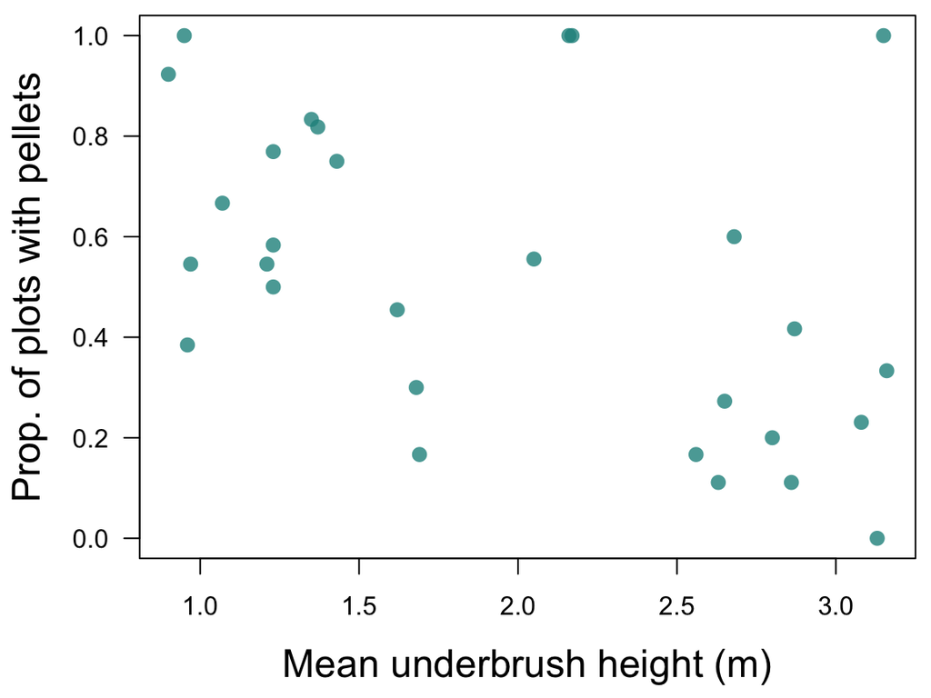

## Elk in clear cuts

A glimpse of the pellet data

```
##    veg_height plots pellets
## 1        2.87    12       5
## 2        1.37    11       9
## 3        2.56    12       2
## 4        2.80    10       2
## 5        3.08    13       3
## 6        2.63     9       1
## 7        1.07     9       6
## 8        2.86     9       1
## 9        1.21    11       6
## 10       1.43    12       9
## 11       2.05     9       5
## 12       2.16    12      12
```

## Elk in clear cuts

```r
## fit model with glm
elk_mod <- glm(cbind(pellets, plots - pellets) ~ veg_height, data = df,
               family = binomial(link = "logit"))
faraway::sumary(elk_mod)
```

```
##             Estimate Std. Error z value  Pr(>|z|)
## (Intercept)  1.61718    0.31737  5.0955 3.477e-07
## veg_height  -0.76954    0.15121 -5.0891 3.598e-07
##
## n = 29 p = 2
## Deviance = 119.08081 Null Deviance = 146.68980 (Difference = 27.60898)
```

## Elk in clear cuts

```r
## original fit
signif(summary(elk_mod)$coefficients, 3)
```

```
##             Estimate Std. Error z value Pr(>|z|)
## (Intercept)     1.62      0.317    5.10 3.48e-07
## veg_height     -0.77      0.151   -5.09 3.60e-07
```

```r
## overdispersion parameter
c_hat <- deviance(elk_mod) / (nn- 1)
## re-scaled estimates
signif(summary(elk_mod, dispersion = c_hat)$coefficients, 3)
```

```
##             Estimate Std. Error z value Pr(>|z|)
## (Intercept)     1.62      0.655    2.47   0.0135
## veg_height     -0.77      0.312   -2.47   0.0136
```

## Quasi-AIC

For binomial models with overdispersion, we can modify AIC

\[ AIC = 2 k - 2 \log \mathcal{L} \]

to be a *quasi*-AIC

\[ QAIC = 2 k - 2 \frac{\log \mathcal{L}}{\hat{c}} \]

## Elk in clear cuts

Model selection results

```
##                     k neg-LL   AIC deltaAIC QAIC deltaQAIC
## intercept + slope   2   90.7 185.4      0.0 46.7       0.0
## intercept only      1  104.5 211.0     25.6 51.1       4.4
```

## Quasi-binomial models

When the data are overdispersed, we can relate the mean and variance of the response to the linear predictor *without* additional information about the binomial distribution

However, this creates problems when we want to make inference via hypothesis tests or CI’s

## Quasi-likelihood

So far we have been using likelihood methods for known distributions

Without a formal distribution for the data, we can use a *quasi-likelihood*

## Quasi-likelihood

Recall that for many distributions we use a *score* \((U)\) as part of the log-likelihood, which can be thought of as

\[ U = \frac{(\text{observation} - \text{expectation})}{\text{scale} \cdot \text{Var}} \]

## Quasi-likelihood

Let’s define the following score

\[ U_i = \frac{(y_i - \mu_i)^2}{\sigma^2 V(\mu_i)} \\ \Downarrow \\ \text{mean}(U) = 0 \\ \text{Var}(U) = \frac{1}{\sigma^2 V(\mu_i)} \\ \]

where \(V(\mu)\) is a function of the covariates

## Quasi-likelihood

We now define \(Q_i\) to be integral over all possible \(y_i\) and \(\mu_i\)

\[ Q_i = \int_{y_i}^{\mu_i} \frac{(y_i - z)^2}{\sigma^2 V(z)} dz \\ \]

which behaves like a log-likelihood function, such that the *quasi-likelihood* for all \(n\) is

\[ Q = \sum_{i = 1}^{n} Q_i \]

## Quasi-likelihood

For example, a normal distribution has a score of

\[ U = \frac{y - \mu}{\sigma^2} \]

and a quasi-likelihood of

\[ Q = -\frac{(y - \mu)^2}{2} \]

## Quasi-likelihood

A binomial has a score of

\[ U = \frac{y - \mu}{\mu(1 - \mu) \sigma^2} \]

and a quasi-likelihood of

\[ Q = y \log \left(\frac{\mu}{1-\mu}\right)+\log (1-\mu) \]

## Quasi-likelihood

We can estimate \(\boldsymbol{\beta}\) by maximizing \(Q\) as with other distributions

But we need to estimate \(\sigma^2\) separately as

\[ \sigma^2 = \frac{X^2}{n - k} \]

where \(X^2\) are the Pearson residuals as defined on slide #26

## Elk in clear cuts

Fitting a quasi-binomial model

```r
## quasi-binomial
elk_quasi <- glm(cbind(pellets, plots - pellets) ~ veg_height,
                 data = df, family = quasibinomial)
faraway::sumary(elk_quasi)
```

```
##             Estimate Std. Error t value Pr(>|t|)
## (Intercept)  1.61718    0.60978  2.6521  0.01323
## veg_height  -0.76954    0.29053 -2.6487  0.01333
##
## Dispersion parameter = 3.69153
## n = 29 p = 2
## Deviance = 119.08081 Null Deviance = 146.68980 (Difference = 27.60898)
```

## Elk in clear cuts

```r
## quasi-binomial
signif(summary(elk_quasi)$coefficients, 3)
```

```
##             Estimate Std. Error t value Pr(>|t|)
## (Intercept)     1.62      0.610    2.65   0.0132
## veg_height     -0.77      0.291   -2.65   0.0133
```

```r
## variance inflation
signif(summary(elk_quasi, dispersion = c_hat)$coefficients, 3)
```

```
##             Estimate Std. Error z value Pr(>|z|)
## (Intercept)     1.62      0.655    2.47   0.0135
## veg_height     -0.77      0.312   -2.47   0.0136
```

## Beta-binomial models

Another option for binomial data is the beta distribution

\[ f(y ; \mu, \phi)=\frac{\Gamma(\phi)}{\Gamma(\mu \phi) \Gamma((1-\mu) \phi)} y^{\mu \phi-1}(1-y)^{(1-\mu) \phi-1} \]

with

\[ \text{mean}(y) = \mu \\ \text{Var}(y) = \frac{\mu(1 - \mu)}{1 + \phi} \]

## Beta-binomial models

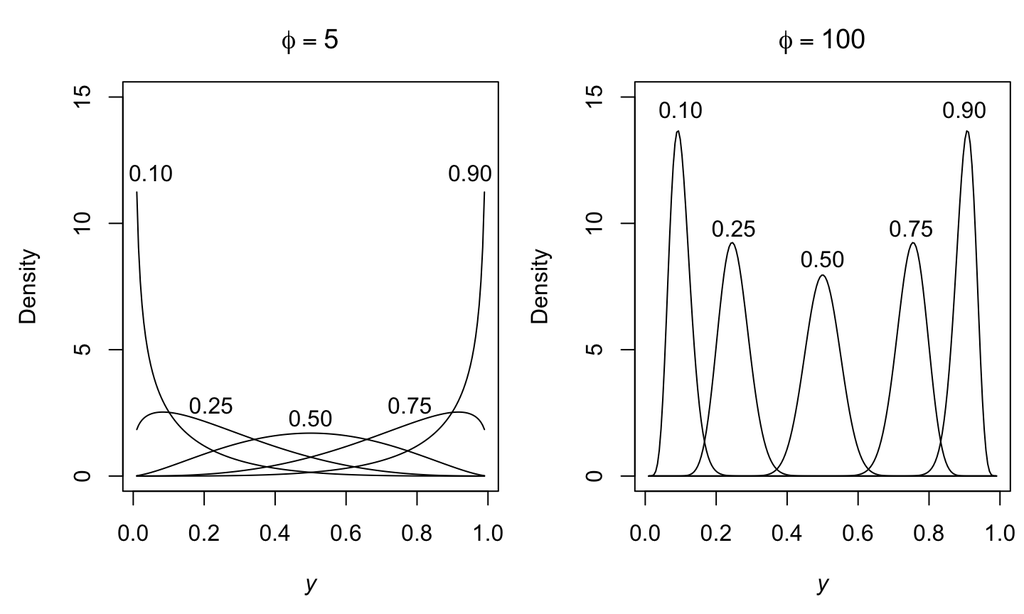

## Beta-binomial models

We can use `gam()` from the **mgcv** package to fit beta-binomial models

```r
## load mgcv
library(mgcv)
## `gam()` needs proportions for the response
df$prop <- df$pellets / df$plots
## weight by num of plots per section
wts <- df$plots / mean(df$plots)
## fit model
elk_betabin <- gam(prop ~ veg_height, weights = wts, data = df,
                   family = betar(link = "logit"))
```

## Beta-binomial models

```r
## inspect beta-binomial fit
summary(elk_betabin)
```

```
##
## Family: Beta regression(0.349)
## Link function: logit
##
## Formula:
## prop ~ veg_height
##
## Parametric coefficients:
##             Estimate Std. Error z value Pr(>|z|)
## (Intercept)   1.1392     0.6559   1.737   0.0824 .
## veg_height   -0.3456     0.3187  -1.085   0.2781
## ---
## Signif. codes:  0 '***' 0.001 '**' 0.01 '*' 0.05 '.' 0.1 ' ' 1
##
##
## R-sq.(adj) =  0.128   Deviance explained = -1.69%
## -REML = -99.423  Scale est. = 1         n = 29
```

## Summary

There are several ways to model overdispersed binomial data, each with its own pros and cons

| Model | Pros | Cons |
| --- | --- | --- |
| binomial | Easy | Underestimates variance |
| binomial with VIF | Easy; estimate of variance | Ad hoc |
| quasi-binomial | Easy; estimate of variance | No distribution for inference |
| beta-binomial | Strong foundation | Somewhat hard to implement |